# More Examples of Time-Dependent Cox Model

Yang Qiao

# More Examples of Time-Dependent Cox Model

This page provides two more complicated examples of time-dependent Cox models. In both examples, we use simulated data where certain covariates may change during follow-up.

- The 1st example looks at one time-varying covariate (Tvc) together with age and gender;
- The 2nd example includes two time-varying covariates at the same time.

For each case, we fit a Cox model and show predicted survival curves, comparing situations where the Tvc changed versus remained unchanged.

## Data Generation

We simulate a small cohort with two fixed covariates (`age` and `gender`) and two time-varying covariates:

- Tvc1 (`X1`) tends to **increase** the hazard (risk of the event) when it happens.
- Tvc2 (`X2`) tends to **decrease** the hazard when it happens.
- The earlier these occur, the **stronger** their effect on hazard.

What this means

- `event = 1` means we observed the event (e.g., death) by time.
- `X1t_time` and `X2t_time` are the days when that time-varying covariate changed. If NA, it didn’t change before the observed time.
- We made Tvc1 (`X1`) harmful on average (increases risk) and Tvc2 (`X2`) protective on average (reduces risk), with earlier times having stronger impact.

```r
set.seed(1)
n <- 50
time_censor <- 160

data <- tibble(id = paste0("s", 1:n)) %>%
  mutate(
    # (1) Add fixed (non time-varying) covariates
    age = sample(30:80, n(), replace = T),
    gender = sample(c("M", "F"), n(), replace = T),

    # (2) Add time-varying covariates X1t and X2t
    X1t_value = rbinom(n(), 1, 0.6),
    X1t_time  = if_else(X1t_value == 1, round(runif(n(), time_censor * 0.1, time_censor * 0.6)), NA),
    X2t_value = rbinom(n(), 1, 0.6),
    X2t_time  = if_else(X2t_value == 1, round(runif(n(), time_censor * 0.1, time_censor * 0.6)), NA),

    # (3) Add event-time response from Weibull distribution
    base_rate   = 0.005 * log10(age),
    effect_X1   = exp(1 * X1t_value * replace_na(1 - X1t_time / time_censor, 0)),
    effect_X2   = exp(-1 * X2t_value * replace_na(1 - X2t_time / time_censor, 0)),
    adj_rate    = base_rate * effect_X1 * effect_X2,
    true_time   = ceiling(rweibull(n(), shape = 2, scale = 1 / adj_rate)),
    true_censor = sample((time_censor / 2):time_censor, n(), replace = T),
    time        = pmin(true_time, true_censor),
    event       = as.integer(true_time <= true_censor),

    # (4) Adjust X1t and X2t if after observed time
    X1t_time   = if_else(!is.na(X1t_time) & X1t_time >= time, NA, X1t_time),
    X1t_value  = if_else(is.na(X1t_time), 0, X1t_value),
    X2t_time   = if_else(!is.na(X2t_time) & X2t_time >= time, NA, X2t_time),
    X2t_value  = if_else(is.na(X2t_time), 0, X2t_value)
  ) %>%
  select(id, event, time, age, gender, X1t_value, X1t_time, X2t_value, X2t_time)

# Quick data check
summary(data)
```

```
##       id                event           time             age           gender
##  Length:50          Min.   :0.00   Min.   :  8.00   Min.   :30.00   Length:50
##  Class :character   1st Qu.:0.00   1st Qu.: 49.25   1st Qu.:47.50   Class :character
##  Mode  :character   Median :1.00   Median : 81.50   Median :59.50   Mode  :character
##                     Mean   :0.64   Mean   : 80.50   Mean   :57.24
##                     3rd Qu.:1.00   3rd Qu.:113.75   3rd Qu.:69.75
##                     Max.   :1.00   Max.   :159.00   Max.   :80.00
##
##    X1t_value       X1t_time       X2t_value       X2t_time
##  Min.   :0.00   Min.   :24.00   Min.   :0.00   Min.   :20.00
##  1st Qu.:0.00   1st Qu.:34.00   1st Qu.:0.00   1st Qu.:26.50
##  Median :0.00   Median :53.00   Median :1.00   Median :30.00
##  Mean   :0.44   Mean   :55.27   Mean   :0.54   Mean   :40.19
##  3rd Qu.:1.00   3rd Qu.:74.75   3rd Qu.:1.00   3rd Qu.:50.50
##  Max.   :1.00   Max.   :93.00   Max.   :1.00   Max.   :95.00
##                 NA's   :28                     NA's   :23
```

```r
print(data, n = Inf)
```

```
## # A tibble: 50 × 9
##    id    event  time   age gender X1t_value X1t_time X2t_value X2t_time
##    <chr> <int> <dbl> <int> <chr>      <dbl>    <dbl>     <dbl>    <dbl>
##  1 s1        0   151    33 F              0       NA         1       41
##  2 s2        1    24    68 F              0       NA         0       NA
##  3 s3        1    47    30 F              0       NA         0       NA
##  4 s4        1    81    63 F              0       NA         0       NA
##  5 s5        1   111    52 F              1       49         1       29
##  6 s6        0   152    72 F              0       NA         0       NA
##  7 s7        1    61    43 M              1       43         0       NA
##  8 s8        1    13    47 F              0       NA         0       NA
##  9 s9        0    81    80 F              0       NA         1       30
## 10 s10       0    82    62 F              0       NA         1       21
## 11 s11       0   117    50 F              1       83         1       25
## 12 s12       0    94    50 M              1       84         1       47
```

[output cut: 38 more lines]

## 1. Cox model with one time-varying covariate and multiple fixed covariates

```r
# Build start–stop data with a single time-varying covariate tvc (for X1)
data_td <- data %>%
  tmerge(., ., id = id, event = event(time, event), tvc = tdc(X1t_time, X1t_value)) %>%
  mutate(across(tvc, ~ replace_na(., 0)))
# Fit Cox model: hazard ~ X1(t) + age + gender
model <- coxph(Surv(tstart, tstop, event) ~ tvc + age + gender, data = data_td, id = id, timefix = F)
summary(model)
```

```
## Call:
## coxph(formula = Surv(tstart, tstop, event) ~ tvc + age + gender,
##     data = data_td, id = id, timefix = F)
##
##   n= 72, number of events= 32
##
##              coef exp(coef)  se(coef)      z Pr(>|z|)
## tvc      0.821340  2.273545  0.419311  1.959   0.0501 .
## age     -0.008835  0.991204  0.013133 -0.673   0.5011
## genderM  0.081316  1.084714  0.360174  0.226   0.8214
## ---
## Signif. codes:  0 '***' 0.001 '**' 0.01 '*' 0.05 '.' 0.1 ' ' 1
##
##         exp(coef) exp(-coef) lower .95 upper .95
## tvc        2.2735     0.4398    0.9995     5.172
## age        0.9912     1.0089    0.9660     1.017
## genderM    1.0847     0.9219    0.5355     2.197
##
## Concordance= 0.542  (se = 0.059 )
## Likelihood ratio test= 4.22  on 3 df,   p=0.2
## Wald test            = 4.29  on 3 df,   p=0.2
## Score (logrank) test = 4.44  on 3 df,   p=0.2
```

How to read the model

- The coef for `tvc` is the log-hazard ratio when Tvc1 (`X1`) changed.
- exp(coef) = hazard ratio (HR):
- HR > 1: higher instantaneous risk (shorter survival) when Tvc1 (`X1`) changed.
- HR < 1: lower instantaneous risk (longer survival) when Tvc1 (`X1`) changed.
- p-value: evidence that Tvc1 (`X1`) affects hazard, after adjusting for age/gender.

Below we create two scenarios for prediction: Tvc1 unchanged vs Tvc1 changed at a typical time (its median time), holding age at its median and comparing by gender. Note these are model-based survival curves (not raw Kaplan–Meier).

```r
# Create a new data to visualize predicted survival
data_sim <- data.frame(event = 1:0, Xt_time = c(NA, median(data_td$X1t_time, na.rm = T)), Xt_value = 0:1) %>%
  # Use the maximum follow-up time for prediction horizon
  mutate(time = max(data_td$time), .before = 1) %>%
  # Compare by gender at median age
  expand_grid(gender = c("M", "F"), age = median(data_td$age)) %>%
  mutate(id = paste0("s", 1:n()), .before = 1)
data_sim
```

```
## # A tibble: 4 × 7
##   id     time event Xt_time Xt_value gender   age
##   <chr> <dbl> <int>   <dbl>    <int> <chr>  <dbl>
## 1 s1      159     1      NA        0 M         54
## 2 s2      159     1      NA        0 F         54
## 3 s3      159     0      53        1 M         54
## 4 s4      159     0      53        1 F         54
```

```r
# Convert to start–stop format
data_fit <- data_sim %>%
  tmerge(., ., id = id, event = event(time, event), tvc = tdc(Xt_time, Xt_value)) %>%
  mutate(across(tvc, ~ replace_na(., 0)))
data_fit
```

```
##   id time event Xt_time Xt_value gender age tstart tstop tvc
## 1 s1  159     1      NA        0      M  54      0   159   0
## 2 s2  159     1      NA        0      F  54      0   159   0
## 3 s3  159     0      53        1      M  54      0    53   0
## 4 s3  159     0      53        1      M  54     53   159   1
## 5 s4  159     0      53        1      F  54      0    53   0
## 6 s4  159     0      53        1      F  54     53   159   1
```

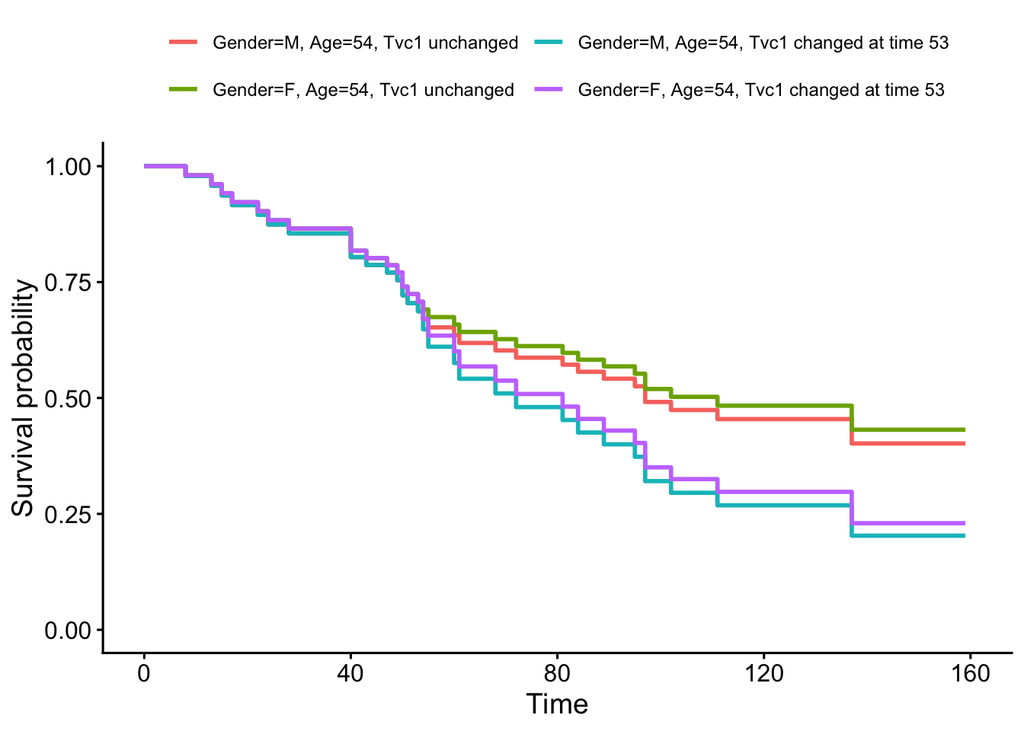

```r
# Fit model-based survival for each individual
fit <- survfit(model, newdata = data_fit, id = id)

# Plot: model-based predicted survival curves
label <- with(data_sim,
              sprintf("Gender=%s, Age=%d, Tvc1 %s", gender, age, if_else(Xt_value == 1, paste("changed at time", Xt_time), "unchanged")))
pp <- ggsurvplot(fit, data_fit, censor = F, legend.labs = label, font.legend = 9)
pp$plot + labs(color = NULL) + guides(color = guide_legend(nrow = 2))
```

## 2. Cox model with two time-varying covariates

```r
# Build start–stop data with two time-varying covariates tvc1 (for X1) and tvc2 (for X2)
data_td <- data %>%
  tmerge(., ., id = id, event = event(time, event), tvc1 = tdc(X1t_time, X1t_value), tvc2 = tdc(X2t_time, X2t_value)) %>%
  mutate(across(c(tvc1, tvc2), ~ replace_na(., 0)))
# Fit Cox model: hazard ~ X1(t) + X2(t)
model <- coxph(Surv(tstart, tstop, event) ~ tvc1 + tvc2, data = data_td, id = id, timefix = F)
summary(model)
```

```
## Call:
## coxph(formula = Surv(tstart, tstop, event) ~ tvc1 + tvc2, data = data_td,
##     id = id, timefix = F)
##
##   n= 99, number of events= 32
##
##         coef exp(coef) se(coef)      z Pr(>|z|)
## tvc1  0.7808    2.1832   0.4086  1.911  0.05602 .
## tvc2 -1.3040    0.2715   0.4708 -2.770  0.00561 **
## ---
## Signif. codes:  0 '***' 0.001 '**' 0.01 '*' 0.05 '.' 0.1 ' ' 1
##
##      exp(coef) exp(-coef) lower .95 upper .95
## tvc1    2.1832      0.458    0.9801    4.8630
## tvc2    0.2715      3.684    0.1079    0.6831
##
## Concordance= 0.638  (se = 0.042 )
## Likelihood ratio test= 11.89  on 2 df,   p=0.003
## Wald test            = 10.93  on 2 df,   p=0.004
## Score (logrank) test = 12.01  on 2 df,   p=0.002
```

How to read the two-tvc model

- `tvc1` HR > 1 means Tvc1 (`X1`) changed increases hazard; HR < 1 means it protects.
- `tvc2` HR > 1 means Tvc2 (`X2`) changed increases hazard; HR < 1 means it protects.
- Signs and magnitudes are adjusted for each other.

We compare the four combinations:

- Tvc1 and Tvc2 unchanged.
- Tvc1 unchanged and Tvc2 changed at its median time.
- Tvc1 changed at its median time and Tvc2 unchanged.
- Tvc1 and Tvc2 changed at their own median time.

```r
# Create a new data to visualize predicted survival
data_sim <- expand_grid(
  data.frame(X1t_time = c(NA, median(data_td$X1t_time, na.rm = T)), X1t_value = 0:1),
  data.frame(X2t_time = c(NA, median(data_td$X2t_time, na.rm = T)), X2t_value = 0:1)
) %>%
  # Use the maximum follow-up time for prediction horizon
  mutate(id = paste0("s", 1:n()), time = max(data_td$time),
         event = c(1L, rep(0L, n() - 1)),
         .before = 1)
data_sim
```

```
## # A tibble: 4 × 7
##   id     time event X1t_time X1t_value X2t_time X2t_value
##   <chr> <dbl> <int>    <dbl>     <int>    <dbl>     <int>
## 1 s1      159     1       NA         0       NA         0
## 2 s2      159     0       NA         0       30         1
## 3 s3      159     0       57         1       NA         0
## 4 s4      159     0       57         1       30         1
```

```r
# Convert to start–stop format
data_fit <- data_sim %>%
  tmerge(., ., id = id, event = event(time, event), tvc1 = tdc(X1t_time, X1t_value), tvc2 = tdc(X2t_time, X2t_value)) %>%
  mutate(across(c(tvc1, tvc2), ~ replace_na(., 0)))
data_fit
```

```
##   id time event X1t_time X1t_value X2t_time X2t_value tstart tstop tvc1 tvc2
## 1 s1  159     1       NA         0       NA         0      0   159    0    0
## 2 s2  159     0       NA         0       30         1      0    30    0    0
## 3 s2  159     0       NA         0       30         1     30   159    0    1
## 4 s3  159     0       57         1       NA         0      0    57    0    0
## 5 s3  159     0       57         1       NA         0     57   159    1    0
## 6 s4  159     0       57         1       30         1      0    30    0    0
## 7 s4  159     0       57         1       30         1     30    57    0    1
## 8 s4  159     0       57         1       30         1     57   159    1    1
```

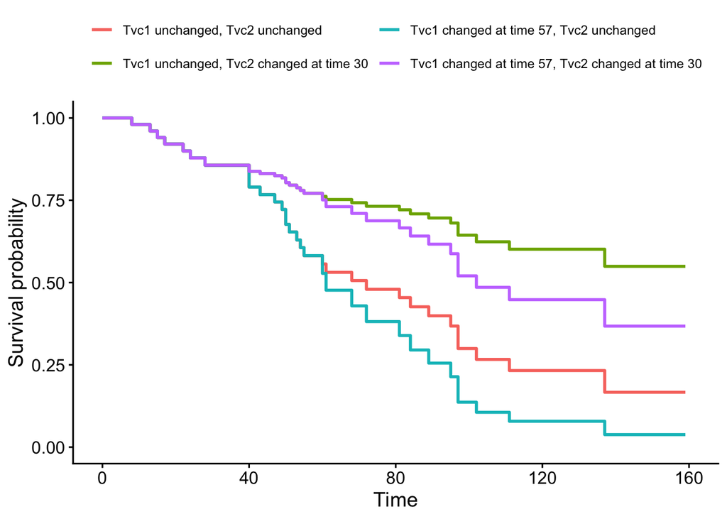

```r
# Fit model-based survival for each individual
fit <- survfit(model, newdata = data_fit, id = id)

# Plot: model-based predicted survival curves
label <- with(data_sim,
              sprintf("Tvc1 %s, Tvc2 %s", if_else(X1t_value == 1, paste("changed at time", X1t_time), "unchanged"),
                      if_else(X2t_value == 1, paste("changed at time", X2t_time), "unchanged")))
pp <- ggsurvplot(fit, data_fit, censor = F, legend.labs = label, font.legend = 9)
pp$plot + labs(color = NULL) + guides(color = guide_legend(nrow = 2))
```